# PCA: Group 03

# 00_all.qmd

# Load data

First the data is gathered from the different websites.

## Load libraries

```r
library(RCurl)
library(jsonlite)
library(dplyr)
library(here)
```

## Create data directory

```r
# Create 'data' directory if it doesn't exist

if (!dir.exists(here("data"))) {dir.create(here("data"))  }

# Create 'raw' directory if it doesn't exist

if (!dir.exists(here("data/_raw"))) {dir.create(here("data/_raw"))  }
```

## Get diabetes data

```r
# Fetch dataset

url <-
  "https://archive.ics.uci.edu/ml/machine-learning-databases/00296/dataset_diabetes.zip"
temp <- tempfile()


download.file(url, temp)

# Unzip files directly into the 'data' directory

unzip(temp, exdir = here("data"))

# The data lies in a subfolder, whichi we would like to remove

path_a <- file.path(here("data"), "dataset_diabetes")
path_b <- file.path(here("data"), "_raw")

# Get the list of files with their full paths from 'path_a'
my_files <- list.files(path_a, full.names = TRUE)

# Copy files to 'path_b'
file.copy(from = my_files, to = path_b, overwrite = TRUE)
```

```
[1] TRUE TRUE
```

```r
# Delete the now-empty folder
unlink(path_a, recursive = TRUE)
```

## Get ICD9 data

```r
# Fetch data
url_ICD9 <- "https://www.cms.gov/medicare/coding/icd9providerdiagnosticcodes/downloads/icd-9-cm-v32-master-descriptions.zip"

temp <- tempfile()

download.file(url_ICD9, temp)

# Unzip files directly into the '_raw' directory
unzip(temp, exdir = here("data/_raw"))

# The zip-folder also contains data on surgaries, which is not relevent here. The unused files are removed
unlink(here("data/_raw/CMS32_DESC_LONG_SG.txt"))
unlink(here("data/_raw/CMS32_DESC_SHORT_SG.txt"))
unlink(here("data/_raw/CMS32_DESC_LONG_SHORT_SG.xlSX"))
unlink(here("data/_raw/CMS32_DESC_LONG_SHORT_DX.xlsx"))
```

# Clean data

The four different files are then combined, and different types of NA values are combined.

## Load libraries

```r
suppressWarnings({
library("tidyverse")
library("here")
library("broom")
})
```

## Clean the meta data

```r
suppressWarnings({
#Data is loaded without defined column names
meta_data <- read_csv(here("data/_raw/IDs_mapping.csv"),
                      na = "",
                      col_names = c("type_id", "description"),
                      show_col_types = FALSE)


# Remove NA columns and add a column based on admission type, that is numeric. The NA values in this, will be the names of the type of metadata the id describes. Also adds a meta_type column, which has the type in the cells that are NAs in the numeric type_id_as_num
meta_data <- meta_data |>
  na.omit() |>
  mutate(type_id,
         type_id_as_num = as.numeric(type_id)) |>
  mutate(meta_type = ifelse(is.na(type_id_as_num),
                            type_id,
                            NA))

#Fills meta_type with the last non-NA cell
meta_data <- meta_data |>
    fill(meta_type)

#Removes the rows containing the names, drops admission_type_is_as_num
meta_data_clean <- meta_data |>
  filter(!is.na(type_id_as_num)) |>
  select(!type_id) |>
  rename(type_id = type_id_as_num)

})

admission_type <- meta_data_clean |>
  filter(meta_type == "admission_type_id") |>
  select(-meta_type) |>
  mutate(description = case_when(description %in% c("NULL", "Not Mapped", "Not Available") ~ NA,
                                 TRUE ~ description))

discharge_disposition <- meta_data_clean |>
  filter(meta_type == "discharge_disposition_id") |>
  select(-meta_type) |>
  mutate(description = case_when(description %in% c("NULL", "Not Mapped", "Unknown/Invalid") ~ NA,
                                 TRUE ~ description))

admission_source <- meta_data_clean |>
  filter(meta_type == "admission_source_id") |>
  select(-meta_type) |>
  mutate(description = case_when(description %in% c("NULL", "Not Mapped", "Unknown/Invalid", "Not Available") ~ NA,
                                 TRUE ~ description))
```

## Clean ICD9 data

The data is downloaded here as the newest version from 2014:

[ICD-9-CM Diagnosis and Procedure Codes: Abbreviated and Full Code Titles | CMS](https://www.cms.gov/medicare/coding-billing/icd-10-codes/icd-9-cm-diagnosis-procedure-codes-abbreviated-and-full-code-titles)

From the files the short and long ds are chosen (sg are surgical and dx are diagnoses).

When running the 01_load.qmd, all the relevant files should be downloaded and placed in data/_raw

```r
# First the data will be loaded into a dataframe of one column
ICD9_short <- read_delim(here("data/_raw/CMS32_DESC_SHORT_DX.txt"),
                 col_names = "data",
                 show_col_types = FALSE,
                 delim = "\n")

ICD9_long <- read_delim(here("data/_raw/CMS32_DESC_LONG_DX.txt"),
                 col_names = "data",
                 show_col_types = FALSE,
                 delim = "\n")

#The long dataset includes é and è in for example Ménière's disease. To deal with this, the data is converted to UTF-8
ICD9_long <- ICD9_long |>
  mutate(data = iconv(data,
        from = "latin1",
        to = "UTF-8",
        sub = "byte"))

# The first value in each row is the ID, but the delimiter is not preserved. Each row is therefore split at the first, and everything else is merged into the second column:

ICD9_short <- ICD9_short |>
  separate(col = data,
           into = c("ID", "Description_short"),
           extra = "merge")

ICD9_long <- ICD9_long |>
  separate(col = data,
           into = c("ID", "Description_long"),
           extra = "merge")

# The long and short dataframe, should have identical IDs, however in case there are some differences, we want all data, and therefore use full_join
ICD9 <- full_join(ICD9_short,
                 ICD9_long,
                 by = "ID")

suppressWarnings({
ICD9 <- ICD9 |>
  mutate(ID = ifelse(str_starts(ID, "[VE]"),
                     ID,
                     as.double(str_c(substr(ID,1,3),
                           ".",
                           substr(ID,4,length(ID))))))
})
```

## Clean diabetes data

```r
diabetes_data <- read_csv(here("data/_raw/diabetic_data.csv"),
                          na = c("?", "None"),
                          show_col_types = FALSE)

#Change NO in readmitted column to No
diabetes_data <- diabetes_data |>
  mutate(readmitted,
         readmitted = str_replace(string = readmitted,
                                  "NO",
                                  "No"))

#Change Ch in change column to Yes
diabetes_data <- diabetes_data |>
  mutate(change,
         change = str_replace(string = change,
                                  "Ch",
                                  "Yes"))
```

## Join information from metadata to diabetes data

```r
full_data <- diabetes_data |>
  left_join(admission_type,
            join_by('admission_type_id' == 'type_id'),
            relationship = "many-to-one") |>
  rename(admission_type = description) |>
  relocate(admission_type, .after = admission_type_id) |>
  select(-admission_type_id)

full_data <- full_data |>
  left_join(admission_source,
            join_by('admission_source_id' == 'type_id'),
            relationship = "many-to-one") |>
  rename(admission_source = description) |>
  relocate(admission_source, .after = admission_source_id) |>
  select(-admission_source_id)

full_data <- full_data |>
  left_join(discharge_disposition,
            join_by('discharge_disposition_id' == 'type_id'),
            relationship = "many-to-one") |>
  rename(discharge_disposition = description) |>
  relocate(discharge_disposition, .after = discharge_disposition_id) |>
  select(-discharge_disposition_id)
```

## Join ICD9 to clean data

```r
full_data <- full_data |>
  left_join(ICD9,
            join_by('diag_1' == 'ID'),
            relationship = "many-to-one",
            na_matches = "never") |>
  rename(diag_1_short = Description_short,
          diag_1_long = Description_long) |>
  mutate(diag_1_short = case_when(is.na(diag_1_short) ~ diag_1,
                                  !is.na(diag_1_short) ~ diag_1_short)) |>
  mutate(diag_1_long = case_when(is.na(diag_1_long) ~ diag_1,
                                 !is.na(diag_1_long) ~ diag_1_long))

full_data <- full_data |>
  left_join(ICD9,
            join_by('diag_2' == 'ID'),
            relationship = "many-to-one",
            na_matches = "never") |>
  rename(diag_2_short = Description_short,
         diag_2_long = Description_long)|>
  mutate(diag_2_short = case_when(is.na(diag_2_short) ~ diag_2,
                                  !is.na(diag_2_short) ~ diag_2_short)) |>
  mutate(diag_2_long = case_when(is.na(diag_2_long) ~ diag_2,
                                  !is.na(diag_2_long) ~ diag_2_long))

full_data <- full_data |>
  left_join(ICD9,
            join_by('diag_3' == 'ID'),
            relationship = "many-to-one",
            na_matches = "never") |>
  rename(diag_3_short = Description_short,
         diag_3_long = Description_long)|>
  mutate(diag_3_short = case_when(is.na(diag_3_short) ~ diag_3,
                                  !is.na(diag_3_short) ~ diag_3_short)) |>
  mutate(diag_3_long = case_when(is.na(diag_3_long) ~ diag_3,
                                  !is.na(diag_3_long) ~ diag_3_long))


full_data <- full_data |>
  relocate(c(diag_1_short,
             diag_2_short,
             diag_3_short,
             diag_1_long,
             diag_2_long,
             diag_3_long), .after = diag_1) |>
  select(-diag_1, -diag_2, -diag_3)
```

## Output clean data

```r
write_csv(full_data, here("data/02_dat_clean.csv"))
```

# Augment data

Two columns are created, one for the amount of encounters per patient and one for the total amount of days the patient has spend in the hospital within the dataset.

## Load libraries

```r
library("here")
library("tidyverse")
```

## Load data

```r
clean_data <- read_csv(here("data/02_dat_clean.csv"))
```

## Encounters in dataset

Add columns that signifies the amount of encounters one patient has in the data set.

```r
clean_data <- clean_data |>
  count(patient_nbr) |>
  right_join(clean_data,
             join_by(patient_nbr)) |>
  rename("nr_encounters" = n) |>
  relocate(c(patient_nbr, nr_encounters),
           .after = encounter_id)
```

## Total time in hospital

Add column for total amount of days spent in hospital

```r
clean_data <- clean_data |>
  group_by(patient_nbr) |>
  summarise(sum(time_in_hospital)) |>
  right_join(clean_data,
             join_by(patient_nbr)) |>
  rename("total_time_hospital" = "sum(time_in_hospital)") |>
  relocate(total_time_hospital,
           .after = time_in_hospital)
```

## Write csv

```r
clean_data <- clean_data |>
  relocate(patient_nbr,
           .after = encounter_id)
write_csv(clean_data, here("data/03_dat_aug.csv"))
write_csv(clean_data, here("R/Shiny_app/03_dat_aug.csv"))
```

# Description

Different key statistics of the data are found.

## Load libraries

```r
library("here")
library("tidyverse")
```

## Load data

```r
aug_data <- read_csv(here("data/03_dat_aug.csv"))
```

### Total amount of encounters:

```r
aug_data |>
  select(encounter_id) |>
  count()
```

```
# A tibble: 1 × 1
       n
   <int>
1 101766
```

### Total amount of patients:

```r
aug_data |>
  distinct(patient_nbr) |>
  count()
```

```
# A tibble: 1 × 1
      n
  <int>
1 71518
```

### Patient with most time spent in hospital

```r
max_time <- aug_data |>
  summarise(max(total_time_hospital)) |>
  pull()

aug_data |>
  distinct(patient_nbr, total_time_hospital) |>
  filter(total_time_hospital == max_time)
```

```
# A tibble: 1 × 2
  patient_nbr total_time_hospital
        <dbl>               <dbl>
1    84428613                 180
```

### Patient with most encounters

```r
max_enc <- aug_data |>
  summarise(max(nr_encounters)) |>
  pull()

aug_data |>
  distinct(patient_nbr, nr_encounters) |>
  filter(nr_encounters == max_enc)
```

```
# A tibble: 1 × 2
  patient_nbr nr_encounters
        <dbl>         <dbl>
1    88785891            40
```

### Patient on most amount of medication

```r
max_med <- aug_data |>
  summarise(max(num_medications)) |>
  pull()

aug_data |>
  distinct(patient_nbr, num_medications) |>
  filter(num_medications == max_med)
```

```
# A tibble: 1 × 2
  patient_nbr num_medications
        <dbl>           <dbl>
1    24189597              81
```

### Patients with most amount diagnoses

```r
max_dia <- aug_data |>
  summarise(max(number_diagnoses)) |>
  pull()

aug_data |>
  distinct(patient_nbr, number_diagnoses) |>
  filter(number_diagnoses == max_dia)
```

```
# A tibble: 45 × 2
   patient_nbr number_diagnoses
         <dbl>            <dbl>
 1    30577455               16
 2    31059126               16
 3    37748088               16
 4    38158101               16
 5    40595031               16
 6    40634091               16
 7    40851090               16
 8    41015448               16
 9    41164047               16
10    41306769               16
# ℹ 35 more rows
```

### Age distribution

```r
aug_data |>
  group_by(age) |>
  count()
```

```
# A tibble: 10 × 2
# Groups:   age [10]
   age          n
   <chr>    <int>
 1 [0-10)     161
 2 [10-20)    691
 3 [20-30)   1657
 4 [30-40)   3775
 5 [40-50)   9685
 6 [50-60)  17256
 7 [60-70)  22483
 8 [70-80)  26068
 9 [80-90)  17197
10 [90-100)  2793
```

### Gender distribution

```r
aug_data |>
  distinct(patient_nbr, gender) |>
  group_by(gender) |>
  count()
```

```
# A tibble: 3 × 2
# Groups:   gender [3]
  gender              n
  <chr>           <int>
1 Female          38026
2 Male            33492
3 Unknown/Invalid     3
```

### Race distribution

```r
aug_data |>
  distinct(patient_nbr, race) |>
  group_by(race) |>
  count()
```

```
# A tibble: 6 × 2
# Groups:   race [6]
  race                n
  <chr>           <int>
1 AfricanAmerican 12932
2 Asian             517
3 Caucasian       53601
4 Hispanic         1534
5 Other            1209
6 <NA>             1977
```

# Visualizations

The data is visualized to discover trends.

## Libraries

```r
library(tidyverse)
library(here)
```

## Load data

```r
data <- read.csv(here("data/03_dat_aug.csv"))
```

## Age distribution

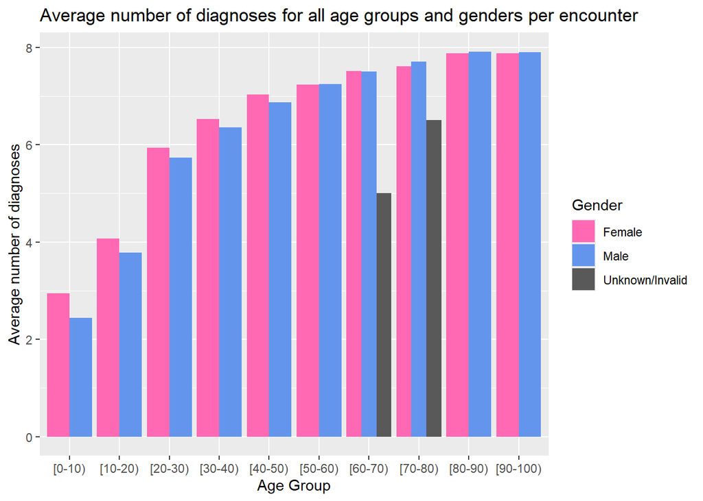

```r
data |>
  group_by(age, gender) |>
  summarise(average_diagnoses = mean(number_diagnoses), .groups = "drop") |>
ggplot(aes(x = age,
                y = average_diagnoses,
                fill = gender)) +
  geom_col(position = "dodge") +
  labs(x = "Age Group",
       y = "Average number of diagnoses",
       fill = "Gender",
       title = "Average number of diagnoses for all age groups and genders per encounter") +
  scale_fill_manual(values=c('hotpink',
                             'cornflowerblue',
                             'grey35'))
```

## Age distribution, shown by race

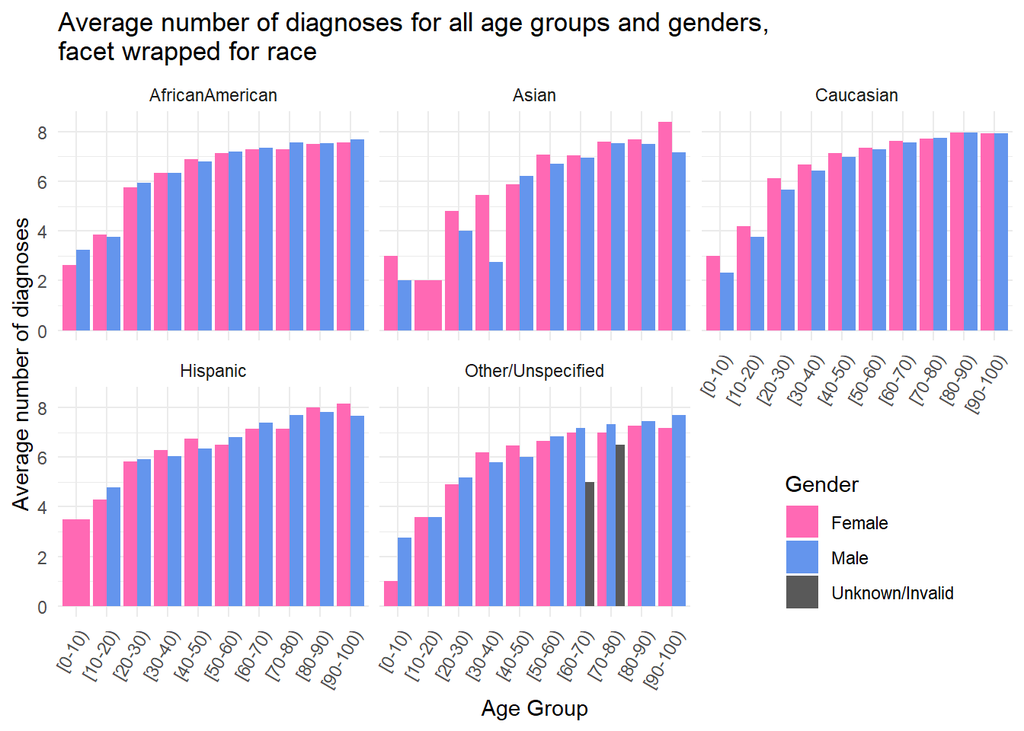

```r
data |>
  mutate(race = ifelse(is.na(race),'Other',race)) |>
  mutate(race = ifelse(race == 'Other', 'Other/Unspecified', race)) |>
  group_by(age,
           gender,
           race) |>
  summarize(average_diagnoses = mean(number_diagnoses), .groups = "drop") |>
  ggplot(mapping = aes(x = age,
                y = average_diagnoses,
                fill = gender)) +
  geom_col(position = "dodge",
           alpha = 1.0) +
  facet_wrap(~ race) +
  labs(
    x = "Age Group",
    y = "Average number of diagnoses",
    fill = "Gender",
    title =
      "Average number of diagnoses for all age groups and genders,\nfacet wrapped for race") +
    scale_fill_manual(values=c('hotpink',
                             'cornflowerblue',
                             'grey35')) +
    theme_minimal() +
    theme(axis.text.x = element_text(angle = 60, hjust =1),
          legend.position = 'inside',
          legend.position.inside = c(0.85,0.15))
```

## Race/gender distribution

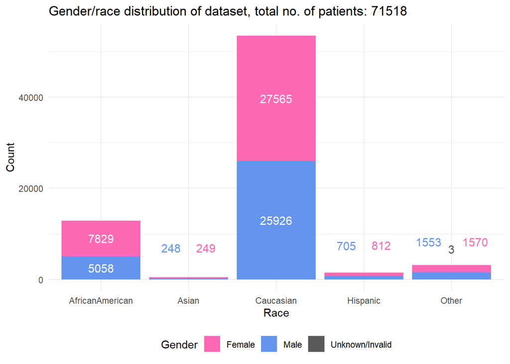

```r
data |>
  select(patient_nbr, race, gender) |>
  distinct(patient_nbr, .keep_all = TRUE) |>
  mutate(race = ifelse(is.na(race), "Other", race)) |>
  group_by(race, gender) |>
  summarise(count = n(), .groups = "drop") |>
  mutate(text_color = ifelse(count > 4000, "white",
                       ifelse(gender == "Female", "hotpink",
                        ifelse(gender == "Male", "cornflowerblue", "grey35")))) |>
  ggplot(aes(x = race, y = count, fill = gender)) +
  geom_bar(stat = "identity", position = "stack") +
  geom_text(
    aes(label = count, color = text_color),
    data = data |>
      select(patient_nbr, race, gender) |>
      distinct(patient_nbr, .keep_all = TRUE) |>
      mutate(race = ifelse(is.na(race), "Other", race)) |>
      group_by(race, gender) |>
      summarise(count = n(), .groups = "drop") |>
      filter(count > 4000) |>
      mutate(text_color = ifelse(count > 4000, "white",
                           ifelse(gender == "Female", "hotpink",
                            ifelse(gender == "Male", "cornflowerblue", "grey35")))),
    position = position_stack(vjust = 0.5),
    size = 4
  ) +
  geom_text(
    aes(label = count, color = text_color),
    data = data |>
      select(patient_nbr, race, gender) |>
      distinct(patient_nbr, .keep_all = TRUE) |>
      mutate(race = ifelse(is.na(race), "Other", race)) |>
      group_by(race, gender) |>
      summarise(count = n(), .groups = "drop") |>
      filter(count <= 4000) |>
      mutate(text_color = ifelse(count > 4000, "white",
                           ifelse(gender == "Female", "hotpink",
                            ifelse(gender == "Male", "cornflowerblue", "grey35")))),
    position = position_dodge2(width = 0.8),
    size = 4,
    vjust = -3
  ) +
  scale_color_identity() +
  labs(
    x = "Race",
    y = "Count",
    fill = "Gender",
    title = str_c("Gender/race distribution of dataset, total no. of patients: ",
                  data |>
                    select(patient_nbr) |>
                    group_by(patient_nbr) |>
                    summarise(count = n()) |>
                    count()
                  )
    ) +
  scale_fill_manual(values = c("hotpink", "cornflowerblue", "grey35")) +
  theme_minimal() +
  theme(legend.position = "bottom")
```

## Discharge disposition

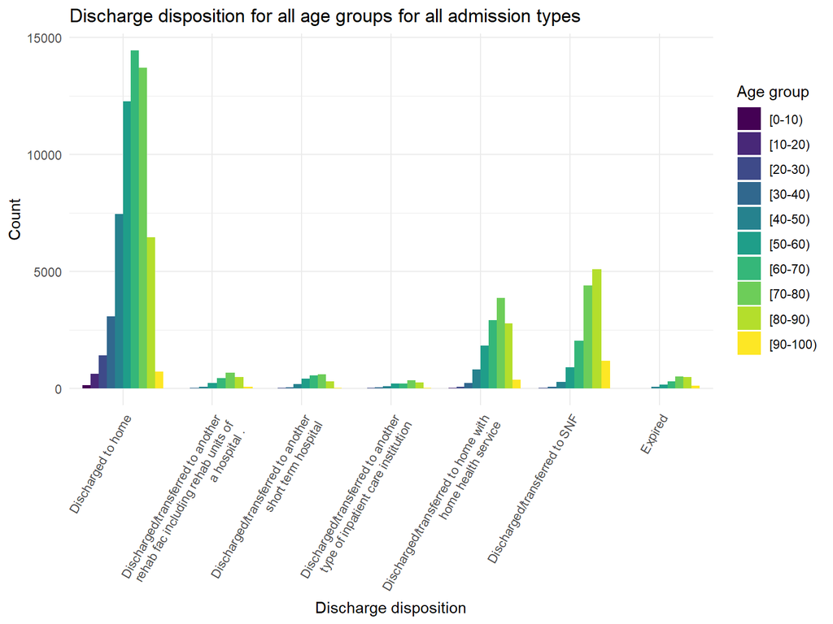

```r
#Finding the 8 most frequent discharge disposition for any admission type
top_8_discharge_dispositions <- data |>
  group_by(discharge_disposition)|>
  summarize(n = n()) |> #Summarizing the total amount of occurences of each discharge type
  arrange(desc(n)) |> #Arranging from high -> low
  head(8) |>
  select(discharge_disposition) |>
  pull() #Converting into a vector

data |>
  select(discharge_disposition, age) |>
  filter(discharge_disposition %in% top_8_discharge_dispositions) |> #Filtering for only the cases where the discharge type was in the top 8
  group_by(discharge_disposition, age) |>
  summarize(n = n(),.groups = 'keep') |>
  drop_na(discharge_disposition) |>
  ggplot(
    mapping = aes(x = discharge_disposition,
                  y = n,
                  fill = age)
  ) +
  geom_col(position = "dodge") +
  scale_fill_viridis_d(option = "viridis") +
  scale_x_discrete(labels = function(x) str_wrap(x, width = 35)) +
  labs(
    x = "Discharge disposition",
    y = "Count",
    fill = "Age group",
    title = "Discharge disposition for all age groups for all admission types"
  ) +
    theme_minimal() +
    theme(
      axis.text.x = element_text(angle = 60, hjust =1)
    )
```

### Only for emergency admission type

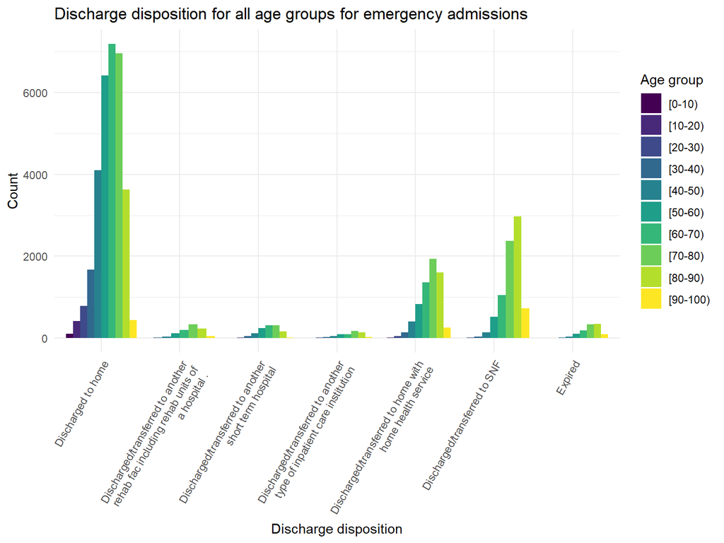

```r
#Finding the top 8 for the casses related to emergency admissions only
top_8_discharge_dispositions <- data |>
  filter(admission_type == "Emergency") |>
  group_by(discharge_disposition)|>
  summarize(n = n()) |>
  arrange(desc(n)) |>
  head(8) |>
  select(discharge_disposition) |>
  pull()

data |>
  filter(admission_type == "Emergency") |>
  select(discharge_disposition, age) |>
  filter(discharge_disposition %in% top_8_discharge_dispositions) |>
  group_by(discharge_disposition, age) |>
  summarize(n = n(),.groups = 'keep') |>
  drop_na(discharge_disposition) |>
  ggplot(
    mapping = aes(x = discharge_disposition,
                  y = n,
                  fill = age)
  ) +
  geom_col(position = "dodge") +
  scale_fill_viridis_d(option = "viridis") +
  scale_x_discrete(labels = function(x) str_wrap(x, width = 35)) +
  labs(
    x = "Discharge disposition",
    y = "Count",
    fill = "Age group",
    title = "Discharge disposition for all age groups for emergency admissions"
  ) +
    theme_minimal() +
    theme(
      axis.text.x = element_text(angle = 60, hjust =1)
    )
```

### Only urgent admission type:

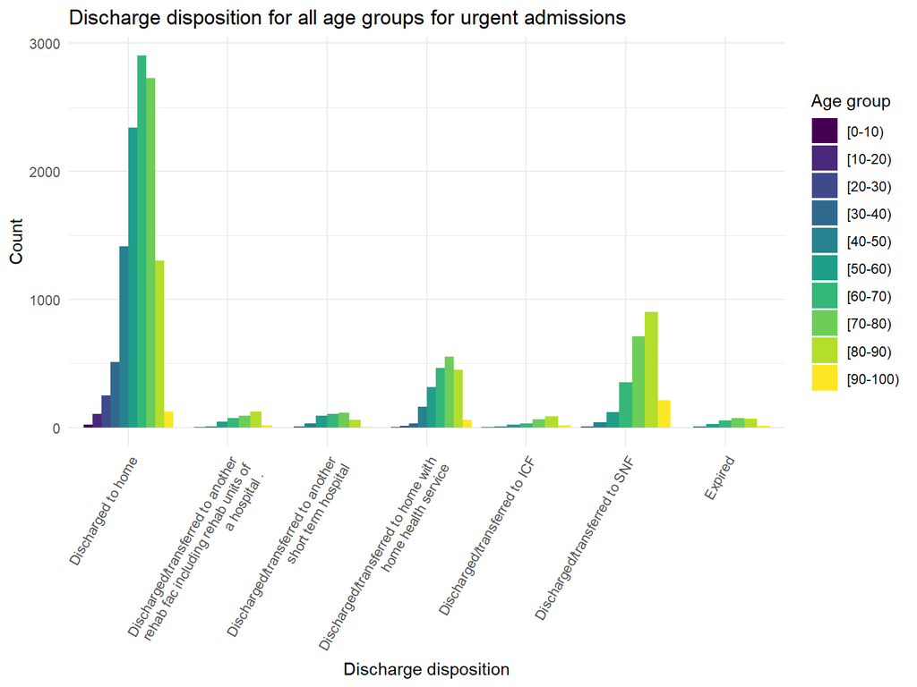

```r
top_8_discharge_dispositions <- data |>
  filter(admission_type == "Urgent") |>
  group_by(discharge_disposition)|>
  summarize(n = n()) |>
  arrange(desc(n)) |>
  head(8) |>
  select(discharge_disposition) |>
  pull()

data |>
  filter(admission_type == "Urgent") |>
  select(discharge_disposition, age) |>
  filter(discharge_disposition %in% top_8_discharge_dispositions) |>
  group_by(discharge_disposition, age) |>
  summarize(n = n(),.groups = 'keep') |>
  drop_na(discharge_disposition) |>
  ggplot(
    mapping = aes(x = discharge_disposition,
                  y = n,
                  fill = age)
  ) +
  geom_col(position = "dodge") +
  scale_fill_viridis_d(option = "viridis") +
  scale_x_discrete(labels = function(x) str_wrap(x, width = 35)) +
  labs(
    x = "Discharge disposition",
    y = "Count",
    fill = "Age group",
    title = "Discharge disposition for all age groups for urgent admissions"
  ) +
    theme_minimal() +
    theme(
      axis.text.x = element_text(angle = 60, hjust =1)
    )
```

### For elective admission type

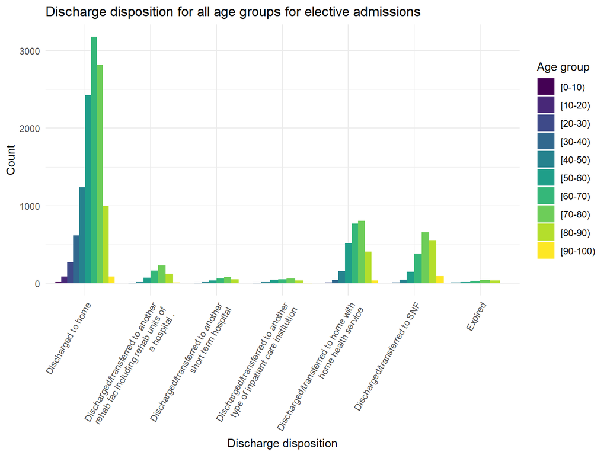

```r
top_8_discharge_dispositions <- data |>
  filter(admission_type == "Elective") |>
  group_by(discharge_disposition)|>
  summarize(n = n()) |>
  arrange(desc(n)) |>
  head(8) |>
  select(discharge_disposition) |>
  pull()

data |>
  filter(admission_type == "Elective") |>
  select(discharge_disposition, age) |>
  filter(discharge_disposition %in% top_8_discharge_dispositions) |>
  group_by(discharge_disposition, age) |>
  summarize(n = n(),.groups = 'keep') |>
  drop_na(discharge_disposition) |>
  ggplot(
    mapping = aes(x = discharge_disposition,
                  y = n,
                  fill = age)
  ) +
  geom_col(position = "dodge") +

  scale_fill_viridis_d(option = "viridis") +
  scale_x_discrete(labels = function(x) str_wrap(x, width = 35)) +
  labs(
    x = "Discharge disposition",
    y = "Count",
    fill = "Age group",
    title = "Discharge disposition for all age groups for elective admissions"
  ) +
    theme_minimal() +
    theme(
      axis.text.x = element_text(angle = 60, hjust =1)
    )
```

## Number of visits per patient

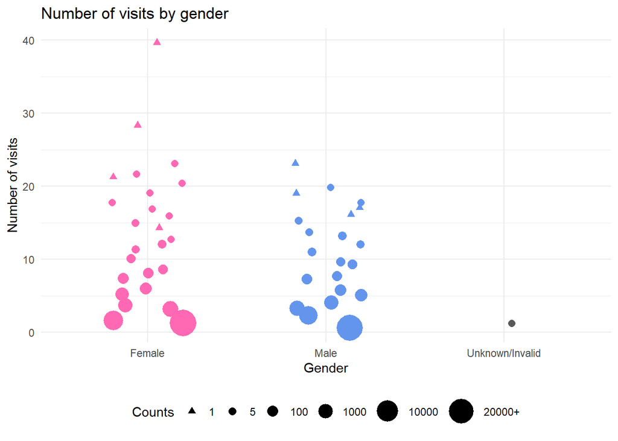

```r
data |>
  select(patient_nbr,gender) |>
  group_by(patient_nbr) |>
  mutate(number_of_visits = n()) |>
  distinct(patient_nbr,.keep_all = TRUE) |>
  ungroup() |>
  select(gender, number_of_visits) |>
  group_by(number_of_visits,gender) |>
  summarise(count = n(), .groups = 'drop') |>
  ggplot(aes(x = number_of_visits, y = gender)) +
  geom_count(aes(color = gender,
                 size = count,
                 shape = factor(count)),
      position = position_jitter(height = 0.2)) +
  labs(x = "Number of visits",
       y = "Gender",
       title = "Number of visits by gender") +
  scale_color_manual(values = c("hotpink", "cornflowerblue", "grey35")) +
  scale_size_continuous(
    range = c(2, 10),
    trans = 'sqrt',
    breaks = c(1, 5, 100, 1000, 10000, 20000),
    labels = c('1', '5', '100', '1000', '10000', '20000+')) +
  scale_shape_manual(values=c(17,rep(16, 28))) +
  theme_minimal() +
  theme(legend.position = 'bottom',
        legend.justification = "center") +
        guides( color = guide_none(),
          size = guide_legend(title = "Counts",
                        override.aes = list(shape = c(17,rep(16,5))),
                        ncol = 6),
          shape = guide_none()) +
  coord_flip()
```

## Diagnosis vs. visits

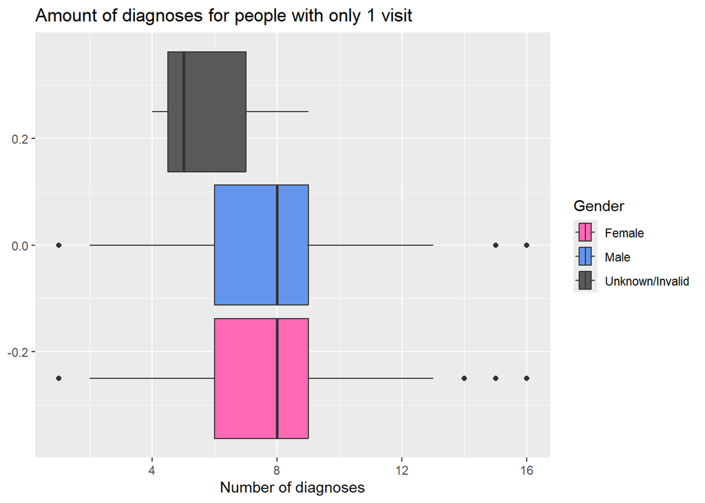

```r
data |>
  filter(nr_encounters == 1) |>
  select(patient_nbr, number_diagnoses, gender) |>
  group_by(patient_nbr) |>
  mutate(visit_num = row_number()) |>
  ungroup() |>
  pivot_wider(
    names_from = visit_num,
    values_from = number_diagnoses,
    names_prefix = "visit_",
    values_fill = list(number_diagnoses = NA)) |>
  ggplot(aes(x=visit_1,fill=gender)) +
  geom_boxplot() +
  labs(title = 'Amount of diagnoses for people with only 1 visit',
       x ='Number of diagnoses',
       fill = 'Gender') +
  scale_fill_manual(values=c('hotpink',
                             'cornflowerblue',
                             'grey35'))
```

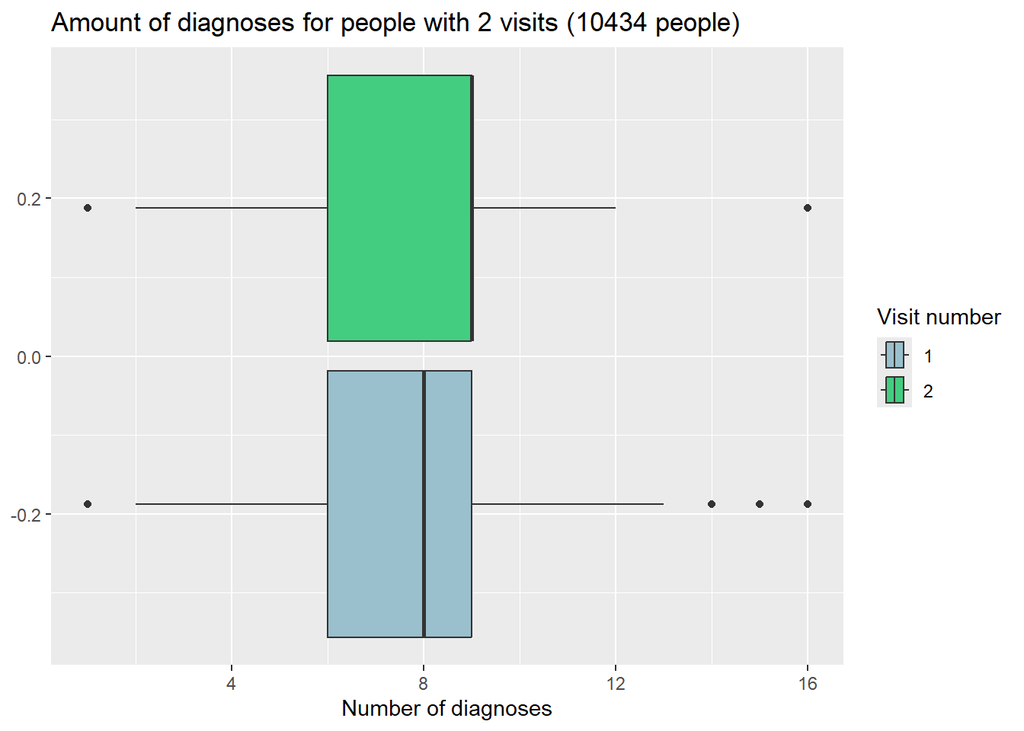

```r
data |>
  filter(nr_encounters == 2) |>
  select(patient_nbr, number_diagnoses,encounter_id) |>
  group_by(patient_nbr) |>
  arrange(encounter_id, .by_group = TRUE) |>
  mutate(visit_num = row_number()) |>
  ungroup() |>
  select(-encounter_id) |>
  pivot_wider(
    names_from = visit_num,
    values_from = number_diagnoses,
    names_prefix = "visit_",
    values_fill = list(number_diagnoses = NA)) |>
  pivot_longer(cols = -patient_nbr,
               names_to = 'visit') |>
  ggplot(aes(x=value,fill=visit)) +
  geom_boxplot() +
  labs(title = str_c('Amount of diagnoses for people with 2 visits (',
                      data |>
                       filter(nr_encounters == 2) |>
                       pull(patient_nbr) |>
                       unique() |>
                       length(),
                     ' people)'),
       x ='Number of diagnoses',
       fill = 'Visit number') +
  scale_fill_manual(
    values = c("visit_1" = "lightblue3", "visit_2" = "seagreen3"),
    labels = c("1", "2")
  )
```

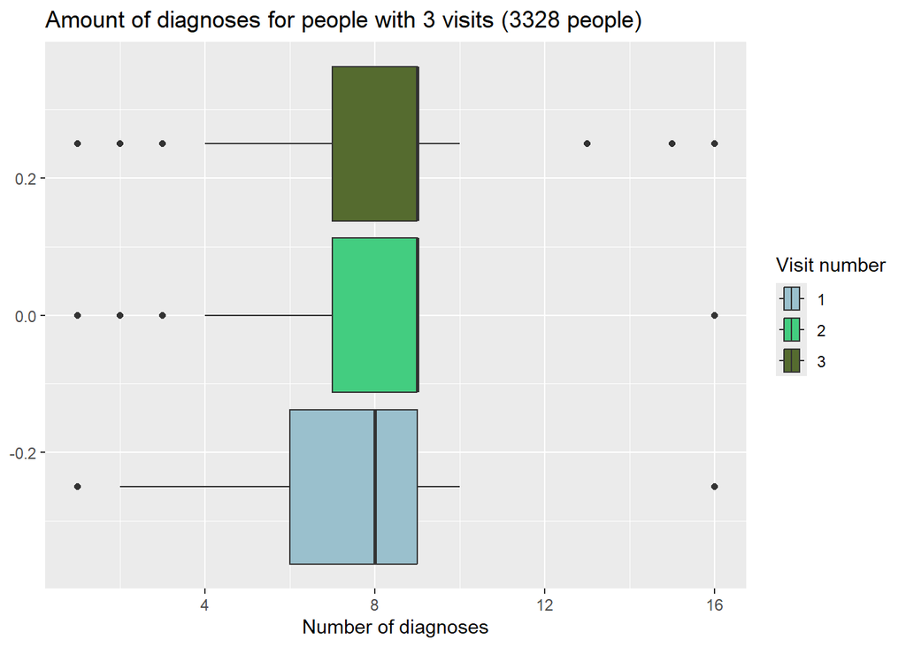

```r
data |>
  filter(nr_encounters == 3) |>
  select(patient_nbr, number_diagnoses, encounter_id) |>
  group_by(patient_nbr) |>
  arrange(encounter_id, .by_group = TRUE) |>
  mutate(visit_num = row_number()) |>
  ungroup() |>
  select(-encounter_id) |>
  pivot_wider(
    names_from = visit_num,
    values_from = number_diagnoses,
    names_prefix = "visit_",
    values_fill = list(number_diagnoses = NA)) |>
  pivot_longer(cols = -patient_nbr,
               names_to = 'visit') |>
  ggplot(aes(x=value,fill=visit)) +
  geom_boxplot() +
  labs(title = str_c('Amount of diagnoses for people with 3 visits (',
                     data |>
                       filter(nr_encounters == 3) |>
                       pull(patient_nbr) |>
                       unique() |>
                       length(),
                     ' people)'),
       x ='Number of diagnoses',
       fill = 'Visit number') +
scale_fill_manual(
    values = c("visit_1" = "lightblue3", "visit_2" = "seagreen3","visit_3" = 'darkolivegreen'),
    labels = c("1", "2","3")
  )
```

## Plot of average of number of diagnosis per patient per maximum visit:

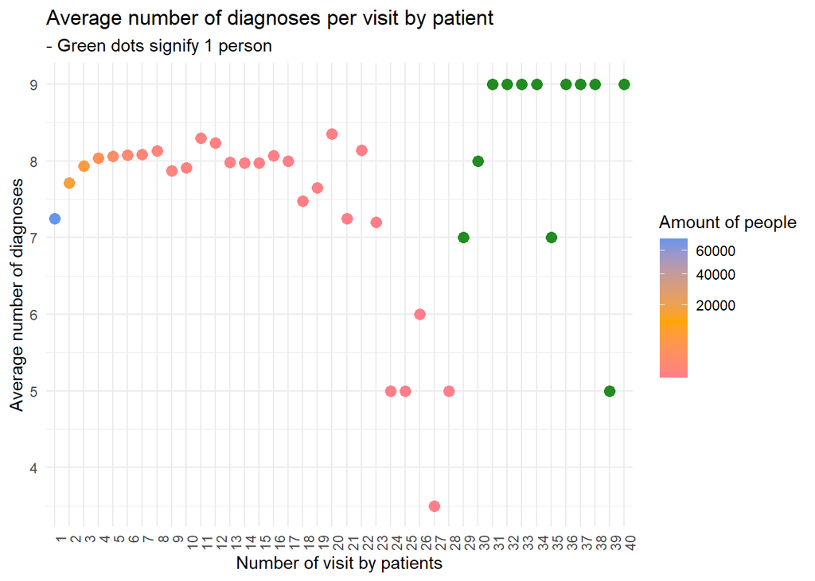

```r
data |>
  select(patient_nbr, number_diagnoses,encounter_id) |>
  group_by(patient_nbr) |>
  arrange(encounter_id, .by_group = TRUE) |>
  mutate(visit_num = row_number()) |>
  ungroup() |>
  select(-encounter_id) |>
  pivot_wider(
    names_from = visit_num,
    values_from = number_diagnoses,
    names_prefix = "visit_",
    values_fill = list(number_diagnoses = NA)) |>
  pivot_longer(cols = c(-patient_nbr),
               names_to = 'visit',
               values_to = 'diagnosis') |>
  drop_na(diagnosis) |>
  group_by(visit) |>
  summarise(mean_diagnosis = mean(diagnosis), no_people = n()) |>
  mutate(visit = str_extract(visit, "\\d+"),
         visit = factor(visit,levels=sort(as.numeric(visit)))) |>
  ggplot(aes(x=visit,y=mean_diagnosis)) +
  geom_point(aes(color=no_people),size=3) +
  scale_color_gradient2(low='hotpink',
                     mid='orange',
                     high='cornflowerblue',
                     midpoint=12000,
                     limits=c(2,NA),
                     n.breaks=5,
                     transform = 'sqrt',
                     na.value = 'forestgreen',
                     guide = guide_colorbar(title = "Amount of people")
                     ) +
  theme_minimal() +
  theme(axis.text.x=element_text(angle=90,hjust=1)) +
  labs(title = 'Average number of diagnoses per visit by patient',
       subtitle = '- Green dots signify 1 person',
       x = 'Number of visit by patients',
       y = 'Average number of diagnoses')
```

## Most common primary diagnoses compared to number of visits

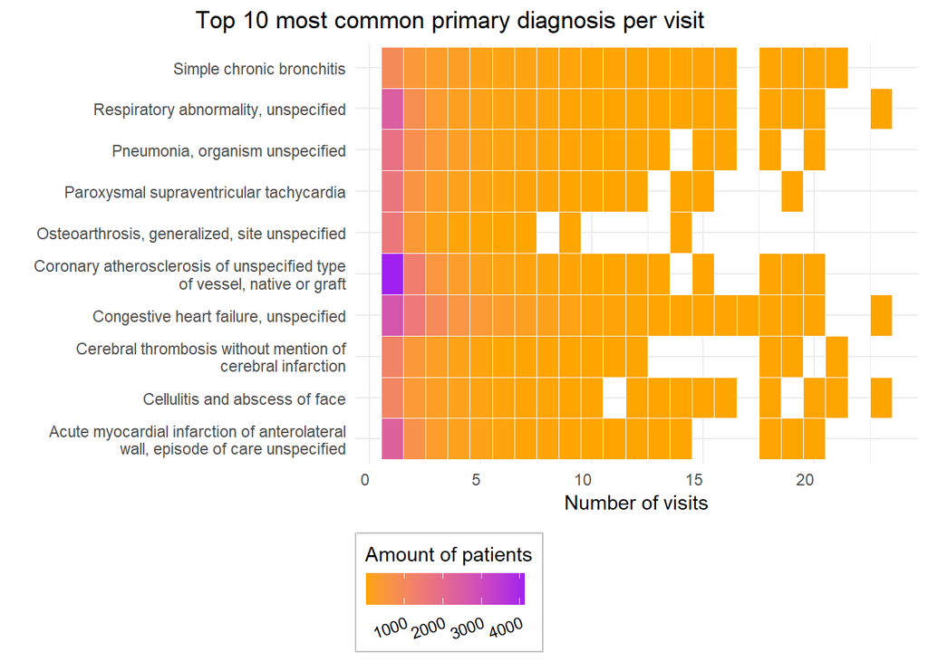

```r
data |>
  select(patient_nbr, encounter_id, nr_encounters, diag_1_long) |>
  group_by(diagnosis = diag_1_long) |>
  summarise(count = n(), .groups = "drop") |>
  top_n(10, count) |>
  inner_join(data, by = c("diagnosis" = "diag_1_long")) |>
  group_by(nr_encounters, diagnosis) |>
  summarise(diagnosis_count = n(), .groups = "drop") |>
  ggplot(aes(x = nr_encounters, y = diagnosis, fill = diagnosis_count)) +
  geom_tile(color = "white") +
  scale_fill_gradient(low = "orange", high = "purple") +
  scale_y_discrete(labels = function(y) str_wrap(y, width = 45)) +
  labs(
    x = "Number of visits",
    y = "",
    fill = "Amount of patients",
    title = "Top 10 most common primary diagnosis per visit"
  ) +
  theme_minimal() +
  theme(axis.text.x = element_text(angle = 0, hjust = 1),
        legend.position = 'bottom',
        legend.background = element_rect(linewidth = 0.5, color = 'grey'),
        legend.text = element_text(angle=20,hjust=1),
        legend.justification = 'left',
        legend.title.position = 'top',
        plot.title = element_text(hjust = -3))
```

### Gender discrepancy for patients

```r
data |>
  group_by(patient_nbr) |>
  filter(n_distinct(gender) > 1) |>
  arrange(encounter_id, .by_group = TRUE)
```

```
# A tibble: 7 × 55
# Groups:   patient_nbr [3]
  encounter_id patient_nbr nr_encounters race      gender age     weight
         <int>       <int>         <int> <chr>     <chr>  <chr>   <chr>
1    220872936    40867677             3 <NA>      Male   [40-50) <NA>
2    232356060    40867677             3 <NA>      Female [40-50) <NA>
3    291975978    40867677             3 <NA>      Male   [40-50) <NA>
4     20729328    55500588             2 Caucasian Female [70-80) <NA>
5     96312942    55500588             2 Caucasian Male   [80-90) <NA>
6    183845022   109210482             2 Caucasian Female [50-60) <NA>
7    186533256   109210482             2 Caucasian Male   [50-60) <NA>
# ℹ 48 more variables: admission_type <chr>, discharge_disposition <chr>,
#   admission_source <chr>, time_in_hospital <int>, total_time_hospital <int>,
#   payer_code <chr>, medical_specialty <chr>, num_lab_procedures <int>,
#   num_procedures <int>, num_medications <int>, number_outpatient <int>,
#   number_emergency <int>, number_inpatient <int>, diag_1_short <chr>,
#   diag_2_short <chr>, diag_3_short <chr>, diag_1_long <chr>,
#   diag_2_long <chr>, diag_3_long <chr>, number_diagnoses <int>, …
```

## Diabetes types

```r
diabetes_count <- data |>
  select(patient_nbr,ends_with('_long')) |>
  pivot_longer(cols = ends_with('_long'),
               values_to = 'all_diagnoses',
               names_to = 'diag_order') |>
  select(-diag_order) |>
  group_by(patient_nbr) |>
  filter(str_detect(all_diagnoses,'iabetes')) |>
  distinct() |>
  group_by(all_diagnoses) |>
  summarise(count=n())
```

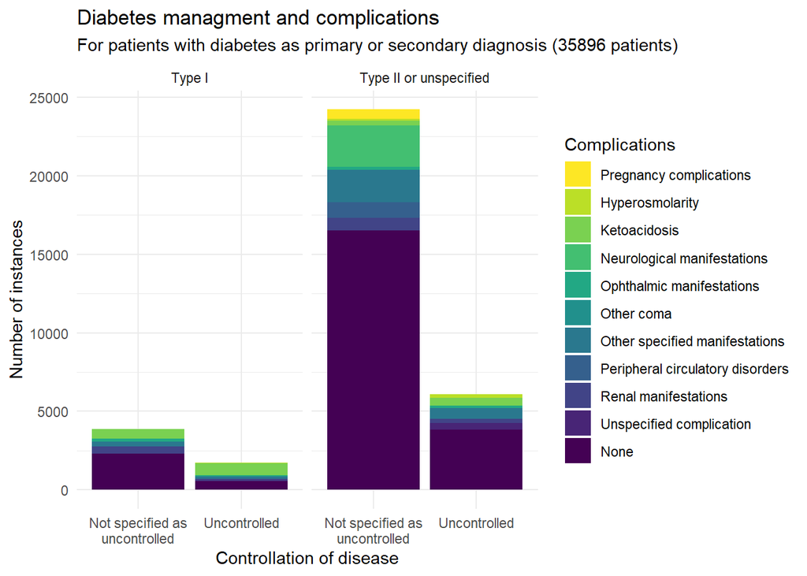

```r
diabetes_count |>
  mutate(type = ifelse(str_detect(all_diagnoses,'type I '),'Type I','Type II or unspecified'),
         uncontrolled = ifelse(str_detect(all_diagnoses,', uncontrolled'),
                               'Uncontrolled', 'Not specified as uncontrolled'),
         no_complication = ifelse(str_detect(all_diagnoses, 'without mention of complication'),
                                  'No complication','Complications')) |>
  mutate(complication_type = ifelse(no_complication == 'Complications',
                                    str_to_sentence(str_extract(all_diagnoses,'(?<=with ).*(?=, *type)')),
                                    'None')) |>
  mutate(complication_type = ifelse(is.na(complication_type),'Pregnancy complications',complication_type)) |>
  mutate(complication_type = factor(complication_type,
                                    levels = c(unique(complication_type[complication_type != 'None']), 'None'))) |>
  ggplot(aes(x = uncontrolled, y=count, fill = complication_type)) +
  geom_bar(stat='identity',) +
  facet_wrap(~type) +
  labs(title = 'Diabetes managment and complications',
       subtitle = str_c('For patients with diabetes as primary or secondary diagnosis (',
                        sum(diabetes_count$count),' patients)'),
       x = 'Controllation of disease',
       y = 'Number of instances',
       fill = 'Complications') +
  theme_minimal() +
  scale_x_discrete(labels = function(x) str_wrap(x,width = 17)) +
  scale_fill_viridis_d(option = 'viridis',direction=-1)
```

### Only for people with complications

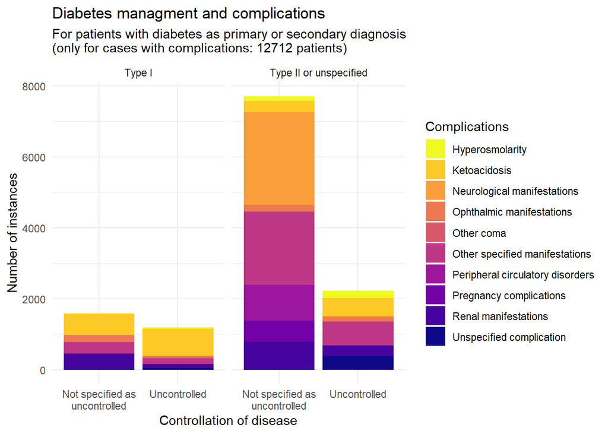

```r
diabetes_count |>
  mutate(type = ifelse(str_detect(all_diagnoses,'type I '),'Type I','Type II or unspecified'),
         uncontrolled = ifelse(str_detect(all_diagnoses,', uncontrolled'),
                               'Uncontrolled', 'Not specified as uncontrolled'),
         no_complication = ifelse(str_detect(all_diagnoses, 'without mention of complication'),
                                  'No complication','Complications')) |>
  mutate(complication_type = ifelse(no_complication == 'Complications',
                                    str_to_sentence(str_extract(all_diagnoses,'(?<=with ).*(?=, *type)')),
                                    'None')) |>
  mutate(complication_type = ifelse(is.na(complication_type),'Pregnancy complications',complication_type)) |>
  filter(!complication_type == 'None') |>
  ggplot(aes(x = uncontrolled, y=count, fill = complication_type)) +
  geom_bar(stat='identity',) +
  facet_wrap(~type) +
  labs(title = 'Diabetes managment and complications',
       subtitle = str_c(
         'For patients with diabetes as primary or secondary diagnosis\n(only for cases with complications: ',
                        diabetes_count |>
                          filter(!str_detect(all_diagnoses,
                                             'without mention of complication')) |>
                          select(count) |>
                          sum(),
                        ' patients)'),
       x = 'Controllation of disease',
       y = 'Number of instances',
       fill = 'Complications') +
  theme_minimal() +
  scale_fill_viridis_d(option = 'plasma',direction=-1) +
  scale_x_discrete(labels = function(x) str_wrap(x,width = 17))
```

# PCA

A PCA is conducted.

### Import dataset

```r
library(tidyverse)
library(broom)
library(cowplot)
library(ggplot2)
library(here)
aug_data <- read_csv(here("data/03_dat_aug.csv"))
```

### Start of the PCA

Looking at the data in PC coordinates:

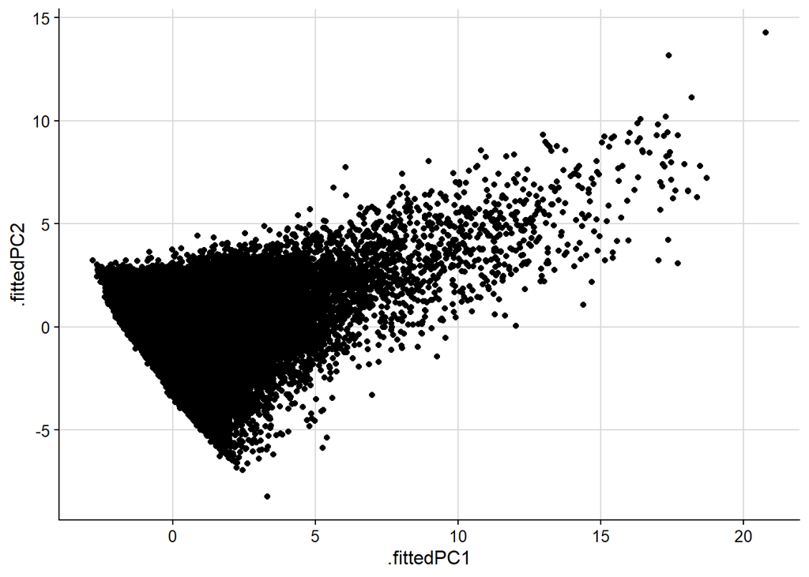

```r
numeric_data <- aug_data |>
  select(where(is.numeric)) |>
  na.omit() |>
  select(where(~ var(., na.rm = TRUE) > 0))

pca_fit <- numeric_data |>
  prcomp(scale = TRUE)

data_clean <- aug_data |>
  filter(row_number() %in% rownames(numeric_data))

pca_plot <- pca_fit |>
  augment(data_clean) |>
  ggplot(aes(.fittedPC1, .fittedPC2)) +
  geom_point(size = 1.5) +
  theme_half_open(12) +
  background_grid()
pca_plot
```

Now we extract the rotation matrix

```r
pca_fit |>
  tidy(matrix = "rotation")
```

```
# A tibble: 144 × 3
   column          PC    value
   <chr>        <dbl>    <dbl>
 1 encounter_id     1  0.0920
 2 encounter_id     2 -0.113
 3 encounter_id     3  0.616
 4 encounter_id     4 -0.00514
 5 encounter_id     5 -0.200
 6 encounter_id     6  0.0289
 7 encounter_id     7  0.166
 8 encounter_id     8  0.0607
 9 encounter_id     9 -0.504
10 encounter_id    10  0.327
# ℹ 134 more rows
```

and plot it:

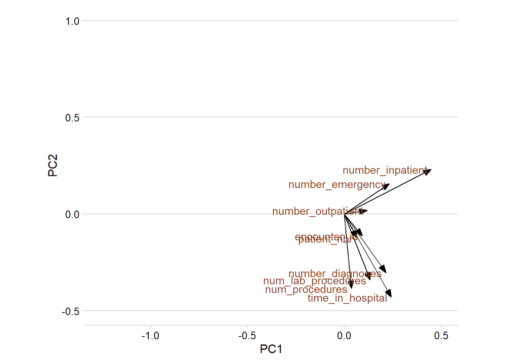

```r
# arrow for plotting
arrow_style <- arrow(
  angle = 20, ends = "first", type = "closed", length = grid::unit(8, "pt")
)

# rotation matrix
pca_fit |>
  tidy(matrix = "rotation") |>
  pivot_wider(names_from = "PC",
              names_prefix = "PC",
              values_from = "value") |>
  ggplot(aes(PC1, PC2)) +
  geom_segment(xend = 0,
               yend = 0,
               arrow = arrow_style) +
  geom_text(
    aes(label = column),
    hjust = 1, nudge_x = -0.02,
    color = "#904C2F"
  ) +
  xlim(-1.25, .5) +
  ylim(-.5, 1) +
  coord_fixed() +
  theme_minimal_hgrid(12)
```

Look at the variance

```r
pca_fit |>
  tidy(matrix = "eigenvalues")
```

```
# A tibble: 12 × 4
      PC std.dev percent cumulative
   <dbl>   <dbl>   <dbl>      <dbl>
 1     1   1.65  0.228        0.228
 2     2   1.39  0.162        0.389
 3     3   1.30  0.141        0.530
 4     4   0.992 0.0820       0.612
 5     5   0.973 0.0788       0.691
 6     6   0.931 0.0723       0.763
 7     7   0.854 0.0607       0.824
 8     8   0.804 0.0538       0.877
 9     9   0.721 0.0433       0.921
10    10   0.682 0.0387       0.959
11    11   0.647 0.0349       0.994
12    12   0.262 0.00572      1
```

And now the plot:

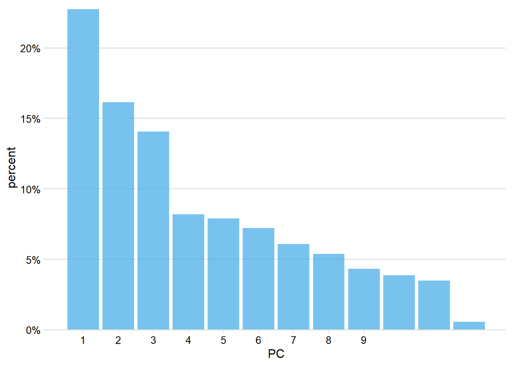

```r
pca_bar_plot <- pca_fit |>
  tidy(matrix = "eigenvalues") |>
  ggplot(aes(PC, percent)) +
  geom_col(fill = "#56B4E9",
           alpha = 0.8) +
  scale_x_continuous(breaks = 1:9) +
  scale_y_continuous(
    labels = scales::percent_format(),
    expand = expansion(mult = c(0, 0.01))
  ) +
  theme_minimal_hgrid(12)
pca_bar_plot
```

### Exporting the key plots

```r
ggsave(
  filename = here("results", "05_pca_plot.png"),
  plot = pca_plot,
  width = 8,
  height = 6,
  dpi = 300
)

ggsave(
  filename = here("results", "05_pca_bar_plot.png"),
  plot = pca_bar_plot,
  width = 8,
  height = 6,
  dpi = 300
)
```

We can then extract what each Principle component is made up of:

```r
# Extract the loadings
loadings <- pca_fit$rotation |>
  as_tibble(rownames = "Variable")

print(loadings)
```

```
# A tibble: 12 × 13
   Variable        PC1     PC2     PC3      PC4     PC5      PC6     PC7     PC8
   <chr>         <dbl>   <dbl>   <dbl>    <dbl>   <dbl>    <dbl>   <dbl>   <dbl>
 1 encounter_id 0.0920 -0.113   0.616  -0.00514 -0.200   0.0289   0.166   0.0607
 2 patient_nbr  0.0647 -0.124   0.604  -0.0877  -0.151   0.00526  0.332   0.148
 3 nr_encounte… 0.507   0.283  -0.0516  0.0250  -0.128   0.143    0.0778 -0.0949
 4 time_in_hos… 0.242  -0.429  -0.227  -0.174    0.0544  0.0330  -0.0464  0.635
 5 total_time_… 0.537   0.136  -0.130  -0.0491  -0.112   0.187    0.0628  0.119
 6 num_lab_pro… 0.134  -0.341  -0.126  -0.543    0.278  -0.279    0.404  -0.465
 7 num_procedu… 0.0368 -0.385  -0.133   0.659   -0.252  -0.0222   0.187  -0.358
 8 num_medicat… 0.221  -0.505  -0.107   0.215   -0.0194 -0.0150   0.0189  0.121
 9 number_outp… 0.118   0.0191  0.214   0.335    0.865   0.260    0.0860  0.0233
10 number_emer… 0.233   0.157   0.118   0.218    0.124  -0.886   -0.164   0.152
11 number_inpa… 0.448   0.230  -0.0274  0.0124  -0.0406  0.0253   0.0706 -0.229
12 number_diag… 0.214  -0.303   0.281  -0.154    0.0167  0.102   -0.782  -0.335
# ℹ 4 more variables: PC9 <dbl>, PC10 <dbl>, PC11 <dbl>, PC12 <dbl>
```

#### Using k-means to cluster patients

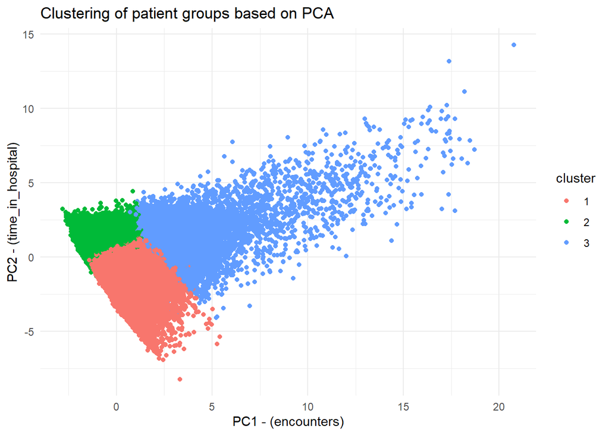

```r
pca_data <- pca_fit |>
  augment(data_clean)

pca_data <- pca_data |>
  mutate(cluster = kmeans(select(pca_data, .fittedPC1:.fittedPC3), centers = 3)$cluster) |>
  mutate(cluster = as.factor(cluster))
pca_data |>
  ggplot(aes(x = .fittedPC1, y = .fittedPC2, color = cluster)) +
  labs(x = "PC1 - (encounters)",
       y = "PC2 - (time_in_hospital)",
       title = "Clustering of patient groups based on PCA") +
  geom_point() +
  theme_minimal()
```

# Shiny

A shiny app is created to discover correlation between readmission and medications.

# Run the Shiny app

shinyApp(ui = ui, server = server)

# Define UI

[output not shown]

library(shiny)